# Capstone Final Report

- Solo: 4 clusters
- Duo: 4 clusters
- Squad: 3 clusters

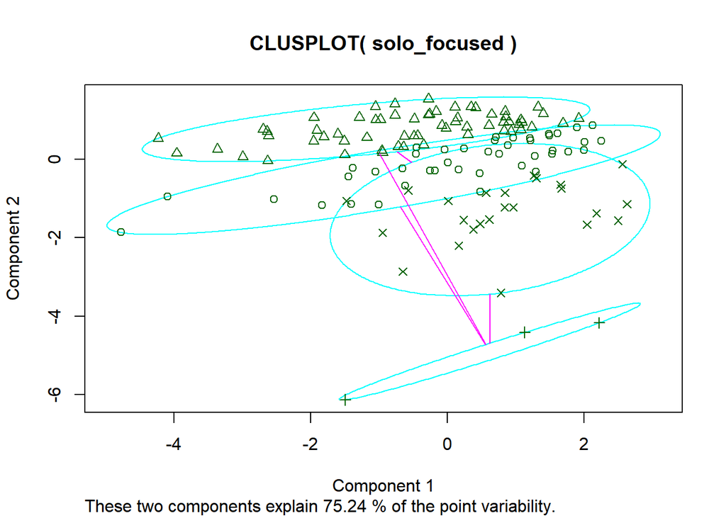

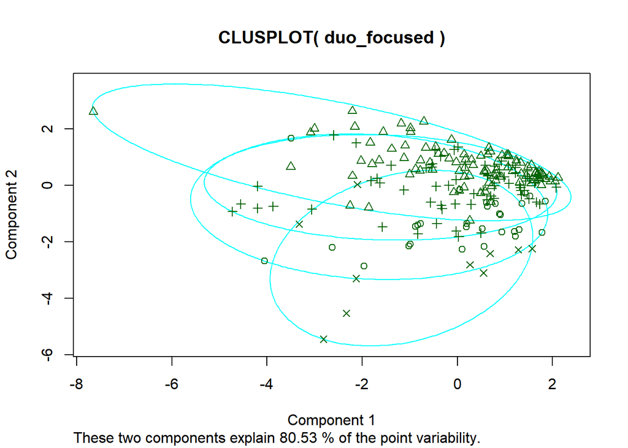

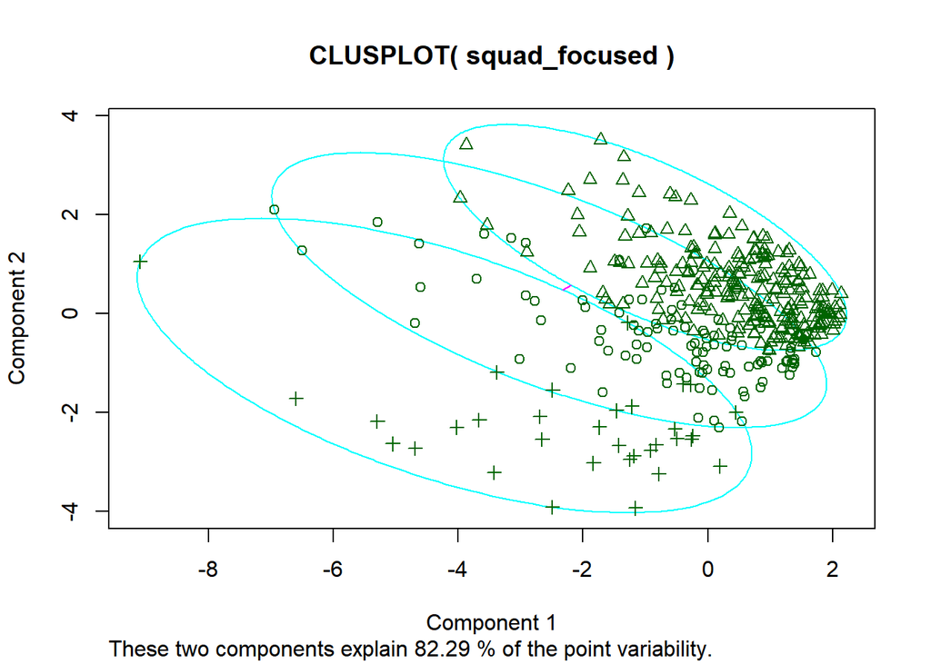

The clusters now look cleaner, and we can now see a better visualization of groups forming within the reduced sample sets.

Once again identifying outliers:

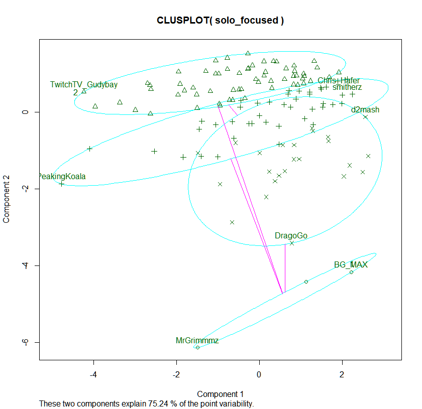

```
## # A tibble: 8 x 6
##   player_name      solo_KillDeathRat~ solo_KillsPg solo_WinRatio solo_Wins
##   <chr>                         <dbl>        <dbl>         <dbl>     <int>
## 1 TwitchTV_Gudybay               6.42         5.40         15.9         33
## 2 Chris_Hafer                    2.23         2.02          9.34        31
## 3 PeakingKoala                   6.14         4.72         23.1         96
## 4 smitherz                       2.16         1.98          8.47        31
## 5 DragoGo                        2.74         2.42         11.8         99
## 6 d2mash                         2.06         1.92          6.62        36
## 7 MrGrimmmz                      4.91         4.50          8.38       103
## 8 BG_MAX                         2.74         2.60          5.06        62
## # ... with 1 more variable: solo_RoundsPlayed <int>
```

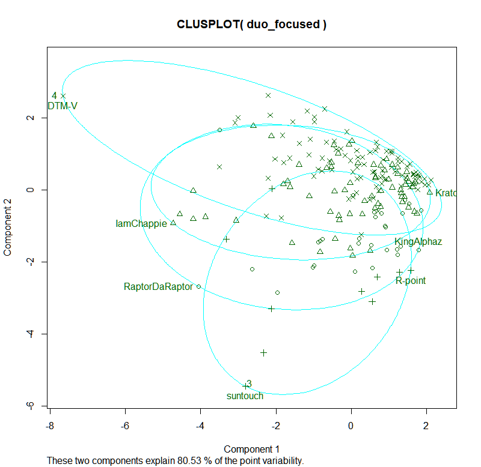

```
## # A tibble: 7 x 6
##   player_name    duo_KillDeathRatio duo_KillsPg duo_WinRatio duo_Wins
##   <chr>                       <dbl>       <dbl>        <dbl>    <int>
## 1 DTM-V                        9.44        5.76         39.1       91
## 2 KratoSD                      2.55        2.26         11.5       33
## 3 IamChappie                   6.01        3.79         37.0      118
## 4 KingAlphaz                   2.52        2.26         10.2       46
## 5 RaptorDaRaptor               4.93        3.18         35.6      139
## 6 R-point                      2.52        2.25         10.6       53
## 7 suntouch                     3.87        3.00         22.5      152
## # ... with 1 more variable: duo_RoundsPlayed <int>
```

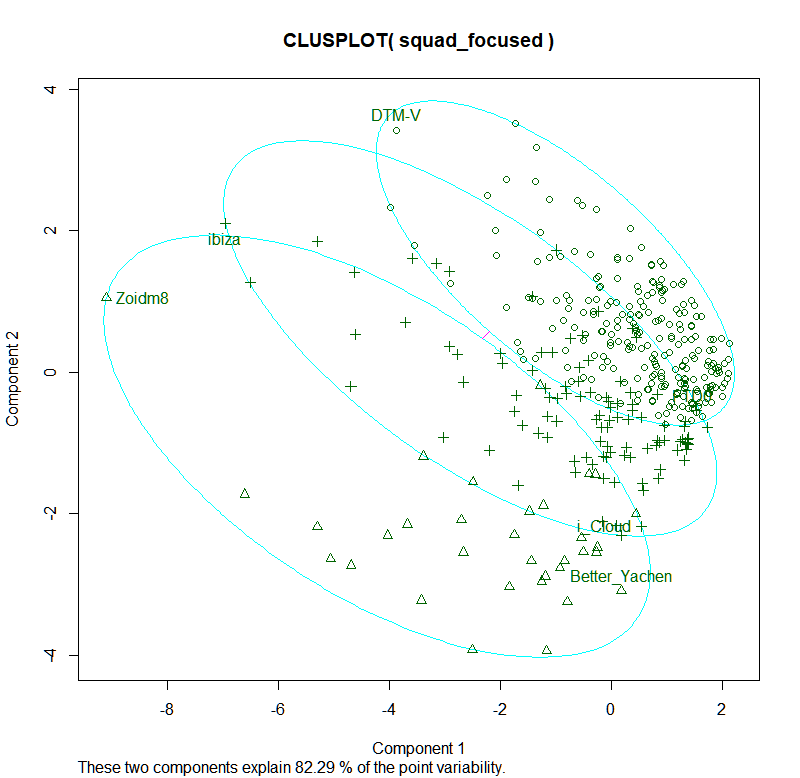

```
## # A tibble: 5 x 6
##   player_name   squad_KillDeathRa~ squad_KillsPg squad_WinRatio squad_Wins
##   <chr>                      <dbl>         <dbl>          <dbl>      <int>
## 1 DTM-V                       9.05          4.36           51.9        111
## 2 ibiza                      11.1           4.73           57.3        252
## 3 Zoidm8                     12.3           5.14           58.2        360
## 4 i_Cloud                     2.56          1.91           25.5        139
## 5 Better_Yachen               2.52          1.97           21.9        156
## # ... with 1 more variable: squad_RoundsPlayed <int>
```

## Conclusion

The clustering did not fully shove consistently separated points. While the outliers were consistent between skimming the data to shrink the overall datasets, the remaining data and the clustering funciton did not give clean cut separations. The clustering did however show us a certain correlation between the number of rounds played compared to the other focused statistics. In the end the listed players from the upper most clusters likely can be observed for interesting gameplay since they stand out from the overall playerbase.

Alternatively another approach to cluster this data would be via player ratings that the game has in the data.